# OpenShift SUM Benchmarking

carljpearson

1/28/2019

### Why should you read this?

This document is about our process and choices in using [the Single Usability Metric (SUM)](https://measuringu.com/sum-2/) to benchmark our products. Read this if you want to learn about the open source R code and specific calculations to use in your own research.

##About

Our organization wanted an empirical measure of the usability of OpenShift Version A and to make a benchmark comparison with OpenShift Version B. This allowed us to give robust evidence for the effect that our design choices had on the usability of our product.

We chose [the Single Usability Metric (SUM)](https://measuringu.com/sum-2/) method to standardize and summarize three classic usability metrics: completion rates, time to completion, and subjective satisfaction. Each of these metrics were collected per user across four tasks: *add a front end container*, *add a database container*, *connect the front end and database*, and *debug a crashing pod (due to misspelled envrionment variable)*. The metrics are created the levels of metrics at each task, each task as a whole, and finaly, each version. The output numbers are based on an NPS-like scale of -100 to 100.

To get these behavioral metrics we recruited 33 users of OpenShift: 20 completed our tasks on version Version A and 13 did so on Version B.

Our organization wanted an empirical measure of the usability of OpenShift Version A and to make a benchmark comparison with OpenShift Version A B. This allowed us to give robust evidence for the effect of our design choices a critical components of the user experience.

####The main research question is *Do our design choices between versions positively affect usability?*

This R Markdown document will walk through the code and results of our research question for the purposes of making the calculation method accessible on free software (R Statistics).

### Load packages and get the data in

```r
#packages
library(tidyverse) #we essentially need dplyr and ggplot2
library(psych) #this is used to calculate a geometric mean
library(ggthemes) #tufte plots let us maximize our data:ink ratio
```

So now we have loaded our packages we will use for calculations and plotting. The essential columns in your long (*not* wide) dataframe must be, respective to our example: participant (factor/numeric), task (factor), time in seconds (numeric), satisfaction (numeric), completion (numeric), group/version (factor).

```r
df <- data_location_local #use your location

head(df) #what do the data look like?
```

```
##   par task time      sat comp group
## 1   3    1   54 5.000000    1     1
## 2   3    2   47 5.000000    1     1
## 3   3    3  362 3.333333    1     1
## 4   3    4  242 5.000000    1     1
## 5   4    1   82 4.666667    1     1
## 6   4    2   78 4.666667    1     1
```

### Precalculation

To calculate confidence intervals, we must choose a critical value. We chose a 90% confidence interval. This means our critical value is as follows:

```r
zval <- 1.64 #z value at 90% confidence
```

Next, we need to choose our benchmarks. For satisfaction, there is a standard value based on past research, which is *4 on a scale out of 1-5*. Completion calculations *do not use a benchmark* (we’ll talk more about this later). Time benchmarks are task specific, and you can [read about how to choose them here](https://measuringu.com/task-times/). A general rule of thumb is the 80-95th percentile fastest time to complete for those who rated satisfaction above 4/5.

```r
df$tspec[df$task==1] <- 90 #time spec for task 1 in seconds #based on derivation from data, 80th percentile from sat above 4 could be used
df$tspec[df$task==2] <- 90 #time spec for task 2 in seconds
df$tspec[df$task==3] <- 120 #time spec for task 3 in seconds
df$tspec[df$task==4] <- 180 #time spec for task 4 in seconds
```

## Calculating

Now we have everything in place to start our calculations. We will calculate each metric separately (classic means and SUM standard means) and then bind the dataframes. All of this can be done in vanilla R, but I find dplyr to speed up my process considerably.

### Satisfaction

To broadly summarize, split by group we get the mean satisfaction of each task. We take each of those means and convert them to a z-score equivalent of a percentage. This gives the standard score that we can combine. Finally, we scale the values to adhere to a -100 to 100 scale. This is similar to the NPS is range and makes it easily digestible to those less familiar with z-scores.

```r
#create satisfaction df -----
df %>%
  group_by(group,task) %>% #group analyses broadly by product/version group and then by each task
  summarise(mean=mean(sat),sd=sd(sat),n=n()) %>% #get means, std deviation, and total observations
  mutate(se=(sd / sqrt(n))) %>% # std error
  mutate(marg=se*zval) %>% #margin of error based on zval
  mutate(lowerci=mean-marg) %>% #lower ci
  mutate(lowerci = ifelse(lowerci <= 0, 0, lowerci)) %>% #keep lower ci above 0
  mutate(upperci=mean+marg) %>% #upper ci
  mutate(upperci = ifelse(upperci >= 5, 5, upperci)) %>% #keep upper ci below max
  mutate(point_est.z = pnorm((mean - 4)/sd)) %>% #z transform based on sd
  mutate(lowerci.z=pnorm((lowerci-4)/sd)) %>%  #z transform lower ci
  mutate(upperci.z=pnorm((upperci-4)/sd)) %>% #z transform upper ci
  mutate(point_est.nps=(point_est.z - .5) * 200)%>% #nps-ify
  mutate(lowerci.nps=(lowerci.z- .5 )* 200)%>% #nps-ify
  mutate(upperci.nps=(upperci.z- .5 )* 200)%>% #nps-ify
  mutate(Measure="Satisfaction") %>% #name measure as var
  mutate(spec=4) %>% #define spec var for raw plots
  rename(point.est=mean) -> df_sat

head(df_sat)
```

```
## # A tibble: 6 x 17
## # Groups:   group [2]
##   group  task point.est    sd     n     se  marg lowerci upperci
##   <int> <int>     <dbl> <dbl> <int>  <dbl> <dbl>   <dbl>   <dbl>
## 1     1     1      4.7  0.445    20 0.0994 0.163    4.54    4.86
## 2     1     2      4.43 0.742    20 0.166  0.272    4.16    4.71
## 3     1     3      2.38 0.853    20 0.191  0.313    2.07    2.70
## 4     1     4      3.38 1.17     20 0.261  0.428    2.96    3.81
## 5     2     1      4.87 0.256    13 0.0710 0.116    4.76    4.99
## 6     2     2      4.77 0.394    13 0.109  0.179    4.59    4.95
## # … with 8 more variables: point_est.z <dbl>, lowerci.z <dbl>,
## #   upperci.z <dbl>, point_est.nps <dbl>, lowerci.nps <dbl>,
## #   upperci.nps <dbl>, Measure <chr>, spec <dbl>
```

### Time

For our time-to-complete variable, we mostly do the same thing as satisfaction, except for a few changes.

We filter our incomplete tasks. Incomplete times are time-to-give-up or our cut off time of 10 minutes per task, and we only want to measure time-to-complete specifically.

We take the geometric mean of time rather than the regular mean; this is because time data is almost always positively skewed. A geometric mean can more accurately account for this skew by transforming into log, taking the mean, and then transforming back.

Instead of a standard bechmark across tasks, we have to use individualized benchmarks per task (`tspec`).

We also have to invert our metrics from raw time scores, as more time spent on a task is related to worse usability.

```r
#create time df----
df %>%
  filter(comp==1) %>% #only completed tasks
  group_by(group,task,tspec) %>% #group analyses broadly by product/version group and then by each task, including task time spec
  summarise(mean=geometric.mean(time),sd = sd(time),n=n()) %>% #get mean, sd and n
  mutate(se=(sd / sqrt(n))) %>% #calculate std error
  mutate(marg=se*zval) %>% #calculate margin of error
  mutate(lowerci=mean-marg) %>% #lower ci
  mutate(lowerci = ifelse(lowerci <= 0, 0, lowerci)) %>% #keep lower ci above 0
  mutate(upperci=mean+marg) %>% #upper ci
  mutate(point_est.z = 1-pnorm((mean - tspec)/sd)) %>% #reverse proportion of z
  mutate(upperci.z=1-pnorm((lowerci-tspec)/sd)) %>% #upperci comes from lowerci after inversion
  mutate(lowerci.z=1-pnorm((upperci-tspec)/sd)) %>% #lowerci comes from upperci after inversion
  mutate(point_est.nps=(point_est.z - .5) * 200)%>% #nps-ify
  mutate(lowerci.nps=(lowerci.z- .5 )* 200)%>% #nps-ify
  mutate(upperci.nps=(upperci.z- .5 )* 200)%>%# nps-ify
  rename(point.est=mean,spec=tspec) %>% #rename some variables to fit into bind_rows
  mutate(Measure="Time") -> df_time

head(df_time)
```

```
## # A tibble: 6 x 17
## # Groups:   group, task [6]
##   group  task  spec point.est    sd     n    se  marg lowerci upperci
##   <int> <int> <dbl>     <dbl> <dbl> <int> <dbl> <dbl>   <dbl>   <dbl>
## 1     1     1    90      62.4  76.5    20 17.1   28.0    34.4    90.5
## 2     1     2    90      83.7  81.4    20 18.2   29.9    53.8   114.
## 3     1     3   120     395.  105.      4 52.5   86.1   309.    481.
## 4     1     4   180     365.  316.     11 95.2  156.    209.    521.
## 5     2     1    90      50.8  35.9    13  9.97  16.4    34.4    67.1
## 6     2     2    90      52.7  29.4    13  8.17  13.4    39.3    66.1
## # … with 7 more variables: point_est.z <dbl>, upperci.z <dbl>,
## #   lowerci.z <dbl>, point_est.nps <dbl>, lowerci.nps <dbl>,
## #   upperci.nps <dbl>, Measure <chr>
```

### Completion

We calculate completion differently than both time and satisfaction because completion is a binary variable (0 or 1). Our confidence intervals are calculated using an Adjusted Wald method; this has the best coverage for small sample sizes of binary outcomes. Further, because sample sizes are small, we use a LaPlace point estimate. The LaPlace point estimate backs us away from a point estimate of 100% or 0%, which would be somewhat of an extreme value to have theoretically (that literally all users would pass or fall).

#### Statistical side note:

This does not use a benchmark value (which based on research would be 78%), but takes the mean completion proportion rate per task to convert directly to a percentage. This has its flaws (mainly an inflated value of midrange completion rates from 50%-78%). The alternative would be to use a bernoulli variance calculation with the benchmark of 78%; this is perhaps more problematic as the small sample size leaves us with extreme confidence intervals on the edge of possible proportional outcomes.

```r
#create completion df ----
df %>%
  group_by(group,task) %>% #group analyses broadly by product/version group and then by each task
  summarise(pass=sum(comp),n=n()) %>% #get n successes and n trials
  mutate(prop = pass / n) %>% #exact proportion from succesess/trials
  mutate(laplace = (pass + 1) / (n + 2)) %>% #laplace point estimate
  mutate(p_adj = (n * prop + (zval * zval) / 2) / (n + (zval * zval))) %>% #adjust p for wald calculation
  mutate(n_adj = n + (zval * zval)) %>% #adjust n for wald calculation
  mutate(marg =  zval * sqrt(p_adj * (1 - p_adj) / n_adj)) %>% #wald margin value
  mutate(lowerci = p_adj - marg) %>% #lower wald ci
  mutate(lowerci = ifelse(lowerci <= 0, 0, lowerci)) %>% #keep lower ci above 0
  mutate(upperci = p_adj + marg) %>% #upper wald ci
  mutate(upperci = ifelse(upperci >= 1, 1, upperci)) %>% #keep upper ci below 1
  mutate(point_est.z = qnorm(laplace) ) %>% #z score transform based on .78 baseline and bernouli variance
  mutate(lowerci.z= qnorm(laplace)-qnorm(marg) ) %>% #z score transform for conf intervals
  mutate(upperci.z = qnorm(laplace)+qnorm(marg) ) %>% #z score transform for conf intervals
  rename(point.est=laplace) %>% #rename
  mutate(point_est.nps=(point.est - .5) * 200)%>% #nps-ify
  mutate(lowerci.nps=(lowerci- .5 )* 200)%>% #nps-ify
  mutate(upperci.nps=(upperci- .5 )* 200)%>%# nps-ify
  mutate(Measure="Completion") %>% #name measure as var
  mutate(spec=.78 #define spec var for raw plots
  ) -> df_comp

head(df_comp)
```

```
## # A tibble: 6 x 19
## # Groups:   group [2]
##   group  task  pass     n  prop point.est p_adj n_adj   marg lowerci
##   <int> <int> <int> <int> <dbl>     <dbl> <dbl> <dbl>  <dbl>   <dbl>
## 1     1     1    20    20  1        0.955 0.941  22.7 0.0813  0.859
## 2     1     2    20    20  1        0.955 0.941  22.7 0.0813  0.859
## 3     1     3     4    20  0.2      0.227 0.236  22.7 0.146   0.0895
## 4     1     4    11    20  0.55     0.545 0.544  22.7 0.171   0.373
## 5     2     1    13    13  1        0.933 0.914  15.7 0.116   0.798
## 6     2     2    13    13  1        0.933 0.914  15.7 0.116   0.798
## # … with 9 more variables: upperci <dbl>, point_est.z <dbl>,
## #   lowerci.z <dbl>, upperci.z <dbl>, point_est.nps <dbl>,
## #   lowerci.nps <dbl>, upperci.nps <dbl>, Measure <chr>, spec <dbl>
```

Then we combine all our newly created dataframes into one. We also clean up some labels.

```r
#bind all the dataframes we just made into one.
bind_rows(df_comp,df_sat,df_time) -> df_summarised

df_summarised <- df_summarised %>%
                    mutate(Group=recode_factor(group,"1"="Version A","2"="Version B")) #rename product groups, ignore errors
```

```r
df_summarised$Group <- as.factor(df_summarised$Group) #make it a factor so it will plot properly, not as numeric
df_summarised$Group <- factor(df_summarised$Group, levels = c("Version A","Version B"))  #reorder factor groups so Version B is last

#add better labels for task varirable, mainly used for plotting more descriptively
df_summarised$task_named[df_summarised$task==1] <- "Task 1: Front End"
df_summarised$task_named[df_summarised$task==2] <- "Task 2: Database"
df_summarised$task_named[df_summarised$task==3] <- "Task 3: Connect"
df_summarised$task_named[df_summarised$task==4] <- "Task 4: Debug"
```

###Plotting

We can begin to plot our data out. This will give us a sense of what tasks have changes in usability metrics. Let’s look at the raw metrics.

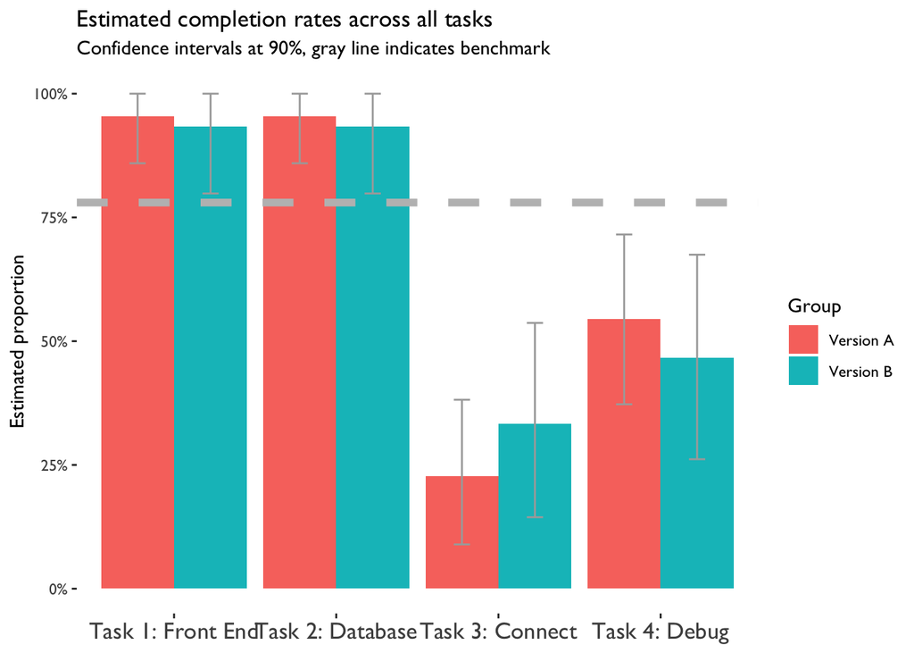

```r
#completion
df_summarised %>%
  filter(Measure=="Completion") %>% #only completion
  ggplot(aes(x=task_named, y=point.est,fill=Group)) +  #variables to plot
  geom_bar(aes(fill=Group), #make a bar plot
           position=position_dodge(), #cluster the bars
           stat="identity") + #use raw numbers to bar location
  geom_abline(intercept=.78,slope=0, color = "gray",linetype = 2, size=2) + #horizontal benchmark line
  coord_cartesian(ylim=c(0,1)) + #limit y axis between 0-1
  geom_errorbar(aes(ymin=lowerci, ymax=upperci),position=position_dodge(.9), stat="identity",color="darkgray",width=.2) + #add error bars
  scale_y_continuous(labels = scales::percent) + #make the y axis a percentage
  labs(x="Task", y="Estimated proportion") + #add proper axis labels
  ggtitle(label = "Estimated completion rates across all tasks", #add titles
          subtitle = "Confidence intervals at 90%, gray line indicates benchmark") +
  ggthemes::theme_tufte(base_family="GillSans") + #add minimal theming
  theme(
    axis.text.x = element_text(size = 13), #adjust text size
    axis.title.x = element_blank()) #remove x axis title
```

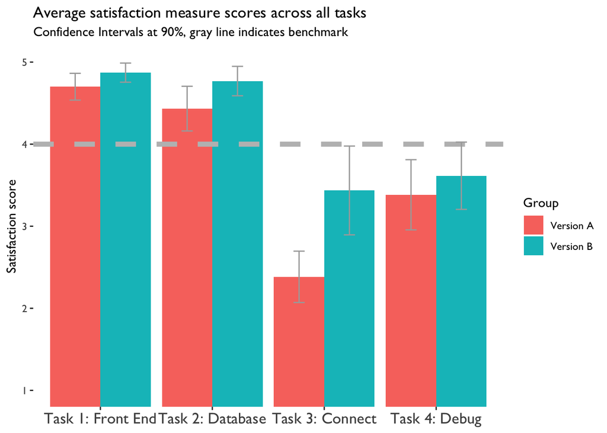

```r
#satisfaction
df_summarised %>%
  filter(Measure=="Satisfaction") %>% #only Satisfaction
  ggplot(aes(x=task_named, y=point.est,fill=Group,ymin=lowerci, ymax=upperci)) + #variables to plot
  geom_bar(aes(fill=Group),#make a bar plot
           position=position_dodge(), #cluser the bars
           stat="identity") + #use raw numbers to bar location
  geom_abline(intercept=4,slope=0, color = "gray",linetype = 2, size=2)+ #add a line for the benchmark
  coord_cartesian(ylim=c(1,5)) + #constrain y axis to 1 and 5
  geom_errorbar(position=position_dodge(.9), stat="identity",color="darkgray",width=.2) + #add error bars
  labs(x="Task", y="Satisfaction score") + #add titles
  ggtitle(label = "Average satisfaction measure scores across all tasks",
          subtitle = "Confidence Intervals at 90%, gray line indicates benchmark") +
  ggthemes::theme_tufte(base_family="GillSans") +  #add minimal theming
  theme(
    axis.text.x = element_text(size = 13), #adjust text size
    axis.title.x = element_blank())  #remove x axis title
```

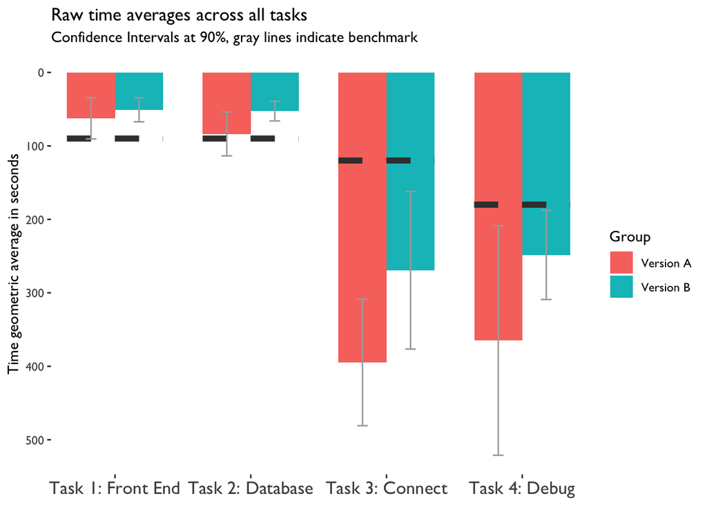

```r
#time
df_summarised %>%
  filter(Measure=="Time") %>%
  group_by(task) %>%
  ggplot(aes(x=task_named, y=point.est,fill=Group)) +
  geom_bar(aes(fill=Group),position=position_dodge(), stat="identity") +
  geom_errorbar(aes(ymax=spec,ymin=spec),position=position_dodge(), stat="identity", color = "#3C3C3C",linetype = 2, size=2)+
  #coord_cartesian(ylim=c(0,1)) +
  geom_errorbar(aes(ymin=lowerci, ymax=upperci),position=position_dodge(.9), stat="identity",color="darkgray",width=.2) +
  labs(x="Task", y="Time geometric average in seconds") +
  ggtitle(label = "Raw time averages across all tasks",
          subtitle = "Confidence Intervals at 90%, gray lines indicate benchmark") +
  #scale_y_time(labels=date_labels("%M $S"))+
  facet_grid(.~task, scales="free")+
  ggthemes::theme_tufte(base_family="GillSans") +
  scale_y_reverse() +
  theme(
    axis.text.x = element_text(size = 13),
    axis.title.x = element_blank(),
    #legend.position="none",
    strip.background = element_blank(), #remove face label area
    strip.text.x = element_blank() #remove facet label text
  )
```

It’s clear after some time that Task 1 is in the best shape, closely followed by Task 2. Task 3 is in the roughest position and Task 4 is around the middle. There is some improvement across these metrics from Version A to B. We can use our sub-task converted scores to compare measures within tasks on a standard scale.

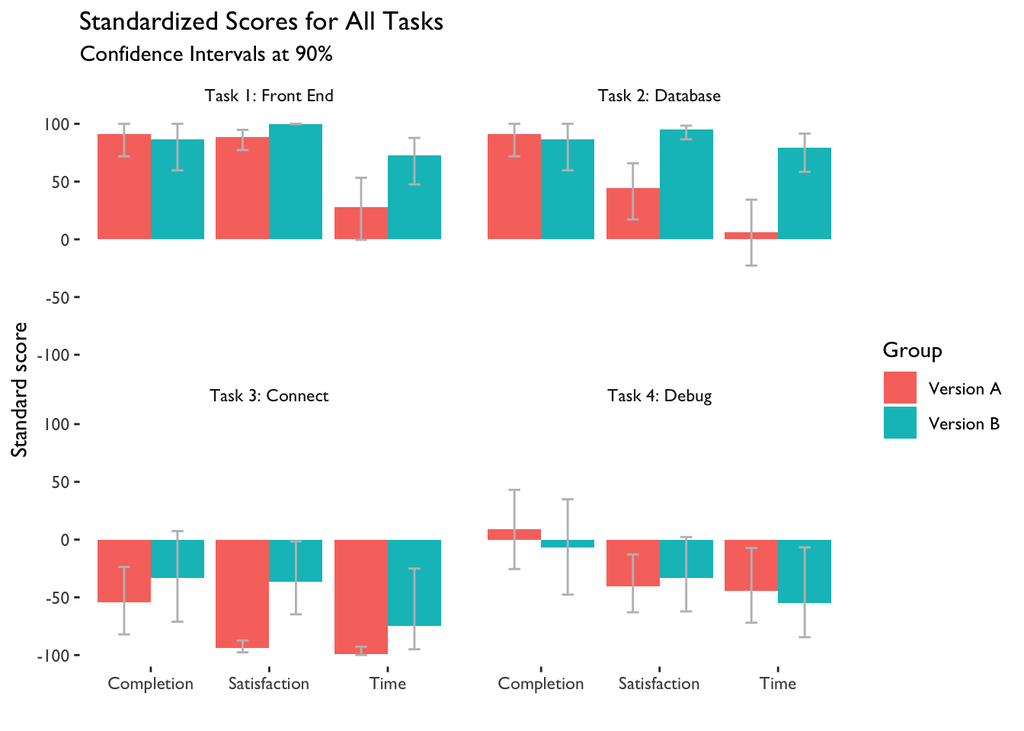

```r
#all sub scores on nps version
df_summarised %>%
  group_by(task_named) %>%
  ggplot(aes(x=Measure, y=point_est.nps,fill=Group)) +
  geom_bar(aes(fill=Group),position=position_dodge(), stat="identity") +
  coord_cartesian(ylim=c(-100,100)) +
  geom_errorbar(aes(ymin=lowerci.nps, ymax=upperci.nps),position=position_dodge(.9), stat="identity",color="gray",width=.2) +
  labs(x="", y="Standard score") +
  ggtitle(label = "Standardized Scores for All Tasks",
          subtitle = "Confidence Intervals at 90%") +
  ggthemes::theme_tufte(base_family="GillSans") +
  facet_wrap(.~task_named)
```

Again, we get the same information as going over the raw plots. And again, it takes a few moments to visually analyze all the data. If we (or a stakeholder) had less time, we can summarize this by looking at the task-level SUM scores.

We need to make a new dataframe for this more summarized view to get a single score for each task based on the sub-metrics. Again, we add some nicer version number labels and descriptive task names.

```r
#Task level SUM score-----
df_summarised %>%
  group_by(group,task) %>% #keep product/versions separate, and only aggregate at task level
  summarise(point_est.z=mean(point_est.z), #average of point estimate std values
            lowerci.z=mean(lowerci.z), #average of lower CI std values
            upperci.z=mean(upperci.z), #average of upper CI std values
            point_est.nps=mean(point_est.nps), #average of pointe estimate NPS-like values
            lowerci.nps=mean(lowerci.nps), #average of lower CI NPS-like values
            upperci.nps=mean(upperci.nps) #average of upper CI NPS-like values
  ) -> df_task

#get better labels for group variable
df_task <- df_task %>%
  mutate(Group=as.factor(recode(group,"1"="Version A","2"="Version B")))
df_task$Group <- as.factor(df_task$Group)
df_task$Group <- factor(df_task$Group, levels = c("Version A","Version B"))


#add better labels for task varirable
df_task$task_named[df_task$task==1] <- "Task 1: Front End"
df_task$task_named[df_task$task==2] <- "Task 2: Database"
df_task$task_named[df_task$task==3] <- "Task 3: Connect"
df_task$task_named[df_task$task==4] <- "Task 4: Debug"
```

With this new dataframe, we can plot task-level scores.

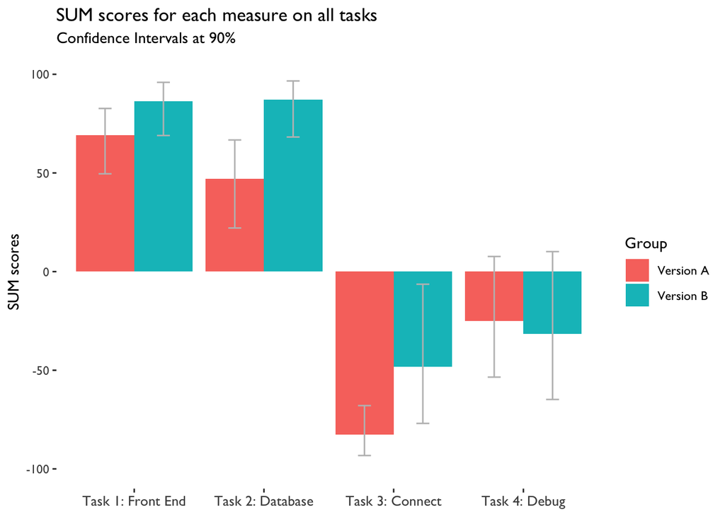

```r
df_task %>%
  ggplot(aes(x=task_named, y=point_est.nps, fill=Group)) + #choose plotting variables
  geom_bar(aes(fill=Group),position=position_dodge(), stat="identity") + #add a clustered bar
  geom_errorbar(aes(ymin=lowerci.nps,  #add error bars
                    ymax=upperci.nps),
                position=position_dodge(.9),
                stat="identity",
                color="gray",width=.2) +
  coord_cartesian(ylim=c(-100,100)) + #choose nps-like axis limits
  labs(title="SUM scores for each measure on all tasks",
      subtitle = "Confidence Intervals at 90%",
      x="",
      y="SUM scores") +
  ggthemes::theme_tufte(base_family="GillSans") + #minimal theming
  theme(
    axis.text.x = element_text(size = 10),
    axis.title.x = element_blank())
```

If we need the simplest, highest level summary, we can plot it by version. (Of course, the sub-metrics are still available for digging into if need be.)

Now the dataframe will come down to just as many rows as you have versions (two, in our case).

```r
#Overall SUM score----

df_summarised %>%
  group_by(group) %>% #keep products separate
  summarise(point_est.z=mean(point_est.z), #average point estimates
            lowerci.z=mean(lowerci.z), #average lower CI
            upperci.z=mean(upperci.z) #average upper CI
  ) %>%
  mutate(point_est.nps=(point_est.z - .5) * 200)%>% #nps-ify
  mutate(lowerci.nps=(lowerci.z- .5 )* 200)%>% #nps-ify
  mutate(upperci.nps=(upperci.z- .5 )* 200 #nps-ify
  )%>%
  mutate(Group=as.factor(recode(group,"1"="Version A","2"="Version B"))) %>% #better labels for version
  mutate(Group=factor(Group, levels = c("Version A","Version B")) #order labels for version
         )-> df_SUM

head(df_SUM)
```

```
## # A tibble: 2 x 8
##   group point_est.z lowerci.z upperci.z point_est.nps lowerci.nps
##   <int>       <dbl>     <dbl>     <dbl>         <dbl>       <dbl>
## 1     1       0.516     0.853     0.183          3.22        70.6
## 2     2       0.602     0.873     0.346         20.4         74.7
## # … with 2 more variables: upperci.nps <dbl>, Group <fct>
```

The final plot will display the version-level scores for the most summarized comparison.

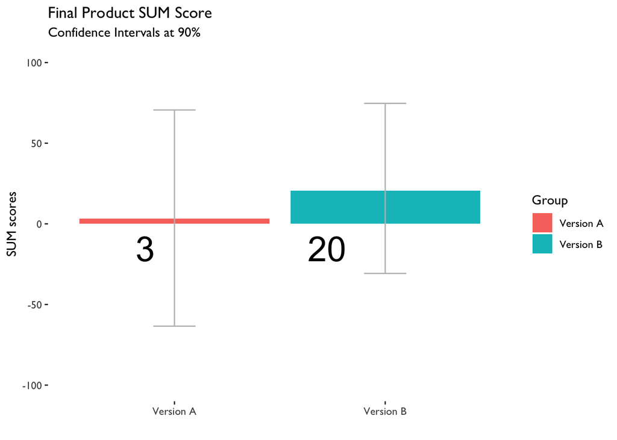

```r
df_SUM %>%
  ggplot(aes(x=Group, y=point_est.nps,fill=Group,ymin=lowerci.nps, ymax=upperci.nps)) + #maps variables
  geom_bar(position=position_dodge(), stat="identity") + #bar graph
  coord_cartesian(ylim=c(-100,100)) + #specificy y axis limits
  geom_errorbar(position=position_dodge(), stat="identity",color="gray",width=.2) + #add error bars
  geom_text(aes(label = round(point_est.nps,0),hjust=2,vjust=1.5,y=0), size = 10, position = "identity") + #add some text for the final SUM numbers
  labs(title = "Final Product SUM Score",
          subtitle = "Confidence Intervals at 90%",
          y="SUM scores",
          x="") +
  ggthemes::theme_tufte(base_family="GillSans") #minimal theming
```